# Information for package authors

## How to use ast2ast

In this paragraph, a basic example demonstrates how to write the R code, translate it and call it from C++. Particular emphasis is placed on the C++ code. First of all, the R function is defined which accepts one argument called *a*, adds two to *a* and stores it into *b*. The variable *b* is returned at the end of the function. The R function called *f* is translated to an external pointer to the *C++* function.

```r
f <- function(a) {
  b <- a + 2
  return(b)
}
library(ast2ast)
f_cpp <- translate(f, output = "XPtr", types_of_args = "sexp", return_type = "sexp")
```

The C++ function depends on RcppArmadillo and ast2ast therefore the required macros and headers were included. Moreover, *ETR* requires std=c++17 therefore the corresponding plugin is added. The function *getXPtr* is defined and is the function which is returned. In the last 5 lines, the translated code is depicted. The function *f* returns a *sexp* and gets one argument of type *sexp* called *a*. The body of the function looks almost identical to the R function. Except that the variable *b* is defined in the first line of the body with the type *sexp*. The function *i2d* converts an integer to a double variable. This is necessary since C++ would identify the *2* as an integer which is not what the user wants in this case.

```cpp
// [[Rcpp::depends(ast2ast, RcppArmadillo)]]
#include <RcppArmadillo.h>
#include <Rcpp.h>
// [[Rcpp::plugins(cpp17)]]
using namespace Rcpp;
using namespace etr;
#include <etr.hpp>
// [[Rcpp::export]]
SEXP getXPtr();

sexp f(sexp a) {
  sexp b;
  b = a + i2d(2);
  return(b);
}
```

Afterwards, the translated R function has to be used in C++ code. This would be your package code for example. First, the macros were defined for *RcppArmadillo* and *ast2ast*. Subsequently, the necessary header files were included. As already mentioned *ast2ast* requires std=c++17 thus the required plugin is included. To use the function, it is necessary to dereference the pointer. The result of the dereferenced pointer has to be stored in a function pointer. Later the function pointer can be used to call the translated function. Therefore, a function pointer called *fp* is defined. It is critical that the signature of the function pointer matches the one of the translated function. Perhaps it would be a good idea to check the R function before it is translated. After defining the function pointer, a function is defined which is called later by the user (called *call_package*). This function accepts the external pointer. Within the function body, a variable *f* is defined of type *fp* and *inp* is assigned to it. Next, a *sexp* object called *a* is defined which stores a vector of length 3 containing 1, 2 and 3. The function *coca* is equivalent to the *c* function R. Afterwards *a* is printed. Followed by the call of the function *f* and storing the result in *a*. The variable *a* is printed again to show that the values are changed according to the code defined in the R function.

```cpp
// [[Rcpp::depends(RcppArmadillo, ast2ast)]]
#include "etr.hpp"
// [[Rcpp::plugins("cpp17")]]
typedef sexp (*fp)(sexp a);
using namespace etr;

// [[Rcpp::export]]
void call_package(Rcpp::XPtr<fp> inp) {
  fp f = *inp;
  sexp a = coca(1, 2, 3);
  print(a);
  a = f(a);
  print("a is now:");
  print(a);
}
```

The user can call now the package code and pass the R function to it. Thus, the user only has to install the compiler or Rtools depending on the operating system. But it is not necessary to write the function in Rcpp.

```r
call_package(f_cpp)
```

```
## 1
## 2
## 3
## a is now:
## 3
## 4
## 5
```

## Rcpp Interface

In the last section, the usage of *ast2ast* was described. However, only *sexp* variables were defined. Which are most likely not used in your package. Therefore interfaces to common libraries are defined. First of all, *ast2ast* can communicate with Rcpp which alleviates working with the library substantially. The code below shows that it is possible to pass a *sexp* object to a variable of type *NumericVector* or *NumericMatrix* and *vice versa*. Here, the data is always copied.

```cpp
// [[Rcpp::depends(ast2ast, RcppArmadillo)]]
#include <RcppArmadillo.h>
#include <Rcpp.h>
// [[Rcpp::plugins(cpp17)]]
using namespace Rcpp;
#include <etr.hpp>
using namespace etr;


// [[Rcpp::export]]
void fct() {
  // NumericVector to sexp
  NumericVector a{1, 2};
  sexp a_ = a;
  print(a_);

  // sexp to NumericVector
  sexp b_ = coca(3, 4);
  NumericVector b = b_;
  Rcpp::Rcout << b << std::endl;

  // NumericMatrix to sexp
  NumericMatrix c(3, 3);
  sexp c_ = c;
  print(c_);

  // sexp to NumericMatrix
  sexp d_ = matrix(colon(1, 16), 4, 4);
  NumericMatrix d = d_;
  Rcpp::Rcout << d << std::endl;
}
```

```r
trash <- fct()
```

```
## 1
## 2
## 3 4
## 0    0   0
## 0    0   0
## 0    0   0
## 1.00000 5.00000 9.00000 13.0000
## 2.00000 6.00000 10.0000 14.0000
## 3.00000 7.00000 11.0000 15.0000
## 4.00000 8.00000 12.0000 16.0000
```

## RcppArmadillo Interface

Besides Rcpp types, *sexp* objects can transfer data to *RcppArmadillo* objects and it is also possible to copy the data from *RcppArmadillo* types to *sexp* objects using the operator *=*. The code below shows that it is possible to pass a *sexp* object to a variable of type *vec* or *mat* and *vice versa*. Here the data is always copied.

```cpp
// [[Rcpp::depends(ast2ast, RcppArmadillo)]]
#include <RcppArmadillo.h>
#include <Rcpp.h>
// [[Rcpp::plugins(cpp17)]]
using namespace arma;
#include <etr.hpp>
using namespace etr;

// [[Rcpp::export]]
void fct() {
  // vec to sexp
  arma::vec a(4, fill::value(30.0));
  sexp a_ = a;
  print(a_);

  // sexp to vec
  sexp b_ = coca(3, 4);
  vec b = b_;
  b.print();

  // mat to sexp
  mat c(3, 3, fill::value(31.0));
  sexp c_ = c;
  print(c_);

  // sexp to mat
  sexp d_ = matrix(colon(1, 16), 4, 4);
  mat d = d_;
  d.print();
}
```

```r
trash <- fct()
```

```
## 30
## 30
## 30
## 30
##    3.0000
##    4.0000
## 31   31  31
## 31   31  31
## 31   31  31
##     1.0000    5.0000    9.0000   13.0000
##     2.0000    6.0000   10.0000   14.0000
##     3.0000    7.0000   11.0000   15.0000
##     4.0000    8.0000   12.0000   16.0000
```

## Pointer Interface

You can pass the information of data stored on heap to a *sexp* object. The constructor for type vector accepts 3 arguments:

- *int* defining the size of the data.
- a pointer (*T**) to the data
- *int* called cob (copy, ownership, borrow).

The constructor for the type matrix accepts 4 arguments:

- *int* defining number of rows
- *int* defining number of cols
- a pointer (*T**) to the data
- *int* called cob (copy, ownership, borrow).

If cob is 0 then the data is copied. Else if cob is 1 then the pointer itself is copied. Meaning that the ownership is transferred to the *sexp* object and the user should not call delete [] on the pointer. Be aware that only one *sexp* variable can take ownership of one vector otherwise the memory is double freed. Else if cob is 2 the ownership of the pointer is only borrowed. Meaning that the *sexp* object cannot be resized. The user is responsible for freeing the memory! The code below shows how the pointer interface works in general. Showing how *sexp* objects can be created by passing the information of pointers (*double**) which hold data on the heap. Currently, only constructors are written which can use the pointer interface.

```cpp
// [[Rcpp::depends(ast2ast, RcppArmadillo)]]
#include <RcppArmadillo.h>
#include <Rcpp.h>
// [[Rcpp::plugins(cpp17)]]
using namespace arma;
#include <etr.hpp>
using namespace etr;

// [[Rcpp::export]]
void fct() {
    int size = 3;

    // copy
    double* ptr1;
    ptr1 = new double[size];
    int cob = 0;
    sexp a(size, ptr1, cob);
    delete [] ptr1;
    a = vector(3.14, 5);
    print(a);

    print();

    // take ownership
    double* ptr2;
    ptr2 = new double[size];
    cob = 1;
    sexp b(size, ptr2, cob);
    b = vector(5, 3);
    print(b);

    print();

    // borrow ownership
    double* ptr3;
    ptr3 = new double[size];
    cob = 2;
    sexp c(size, ptr3, cob);
    //error calls resize
    //c = vector(5, size + 1);
    c = vector(4, size);
    print(c);

    print();
    sexp d(size, ptr3, cob);
    d = d + 10;
    print(d);
    print();

    delete[] ptr3;
}
```

```r
trash <- fct()
```

```
## 3.14
## 3.14
## 3.14
## 3.14
## 3.14
##
## 5
## 5
## 5
##
## 4
## 4
## 4
##
## 14
## 14
## 14
```

The pointer interface is particularly useful if the user function has to change the data of a vector or matrix of type *NumericVector*, *vec*, *NumericMatrix* or *mat*. Assuming that the user passes a function that accepts its arguments by reference it is easy to modify any variable which has a type that can return a pointer to its data. In the code below it is shown how *sexp* objects are constructed using the pointer interface. Thereby changing the content of variables which has an Rcpp type, a RcppArmadillo type, or is of type std::vector.

```cpp
// [[Rcpp::depends(ast2ast, RcppArmadillo)]]
#include <RcppArmadillo.h>
#include <Rcpp.h>
// [[Rcpp::plugins(cpp17)]]
using namespace Rcpp;
using namespace arma;
#include <etr.hpp>
using namespace etr;

typedef void (*fp)(sexp& a);

// [[Rcpp::export]]
void call_package(Rcpp::XPtr<fp> inp) {
  fp f = *inp;

  // NumericVector
  NumericVector a_rcpp{1, 2, 3};
  sexp a(a_rcpp.size(), a_rcpp.begin(), 2);
  f(a);
  Rcpp::Rcout << a_rcpp << std::endl;

  //arma::vec
  vec a_arma(2, fill::value(30));
  sexp b(2, a_arma.memptr(), 2);
  f(b);
  a_arma.print();

  // NumericMatrix
  NumericMatrix c_rcpp(2, 2);
  sexp c(2, 2, c_rcpp.begin(), 2);
  f(c);
  Rcpp::Rcout << c_rcpp << std::endl;

  //arma::mat
  mat d_arma(3, 2, fill::value(30));
  sexp d(3, 2, d_arma.memptr(), 2);
  f(d);
  d_arma.print();
}
```

```r
f <- function(a) {
  a <- a + 2
}

library(ast2ast)
fa2a <- translate(f, reference = TRUE, output = "XPtr", types_of_args = "sexp", return_type = "void")
trash <- call_package(fa2a)
```

```
## 3 4 5
##    32.0000
##    32.0000
## 2.00000 2.00000
## 2.00000 2.00000
##
##    32.0000   32.0000
##    32.0000   32.0000
##    32.0000   32.0000
```

## Example r2sundials

In this section an example is shown to illustrate how *ast2ast* could be used in other R packages. to solve ODE-systems very efficiently. In order to do this the R package *r2sundials* is used. First a wrapper function is created which is then used by *r2sundials*. Probably it would be more efficient when the package code itself would take care of the transfer of data between *Rcpp/RcppArmadillo* and *ast2ast*.

In this example it is shown how ODE-systems can be solved by using *r2sundials* and *ast2ast*. The code below shows how *r2sundials* is used normally. Either using an R function or an external pointer to a C++ function.

```r
library(RcppXPtrUtils)
library(Rcpp)
library(ast2ast)
library(r2sundials)
library(microbenchmark)

# R version
# ==============================================================================
ti <- seq(0, 5, length.out=101)
p <- list(a = 2)
p <- c(nu = 2, a = 1)
y0 <- 0
frhs <- function(t, y, p, psens) {
  -p["nu"]*(y-p["a"])
}

res1 <- r2cvodes(y0, ti,
                    frhs, param = p)



# external pointer version
# ==============================================================================
ptr_exp=cppXPtr(code='
int rhs_exp(double t, const vec &y, vec &ydot, RObject &param, NumericVector &psens) {
  NumericVector p(param);
  ydot[0] = -p["a"]*(y[0]-1);
  return(CV_SUCCESS);
}
', depends=c("RcppArmadillo","r2sundials","rmumps"),
includes="using namespace arma;\n#include <r2sundials.h>", cacheDir="lib", verbose=FALSE)
# For ease of use in C++, we convert param to a numeric vector instead of a list.

pv = c(a= 2)
# new call to r2cvodes() with XPtr pointer ptr_exp.
res3=r2sundials::r2cvodes(y0, ti, ptr_exp, param=pv)
```

In the code below is the wrapper function defined which is later called by *r2sundials*. This function is called *rhs_exp_wrapper* and has the correct function signature. Furthermore, a global function pointer named *Fct* is defined of type *void (**user_fct) (sexp& y_, sexp& ydot_)*. Within* rhs_exp_wrapper* the data of the vectors *y* and *ydot* are used to construct two *sexp* objects which are passed to *Fct*. Thus, the vector *ydot* is modified by the function passed from the user. Furthermore, another function called *solve_ode* is defined. Which calls the code from *r2sundials*, solves the ODE-system, and returns the output to R. In R the user defines the R function *ode*. Next, the function is translated and passed to *solve_ode*. Comparing the results shows that all three approaches (R, C++, *ast2ast*) generate the same result. Afterwards a benchmark is conducted showing that R is substantially slower than C++ and that the translated function is almost as fast as C++. Mentionable, it is possible to increase the speed of the *ast2ast* version by using the *at* function and the *_db* extension.

```cpp
// [[Rcpp::depends(RcppArmadillo)]]
// [[Rcpp::depends(rmumps)]]
// [[Rcpp::depends(r2sundials)]]
// [[Rcpp::depends(ast2ast)]]
// [[Rcpp::plugins("cpp17")]]
#include "etr.hpp"
#include "RcppArmadillo.h"
#include "r2sundials.h"
using namespace arma;
using namespace Rcpp;
using namespace etr;

typedef int (*fp)(double t, const vec &y,
             vec &ydot, RObject &param,
             NumericVector &psens);

typedef void (*user_fct)(sexp& y_,
              sexp& ydot_);
user_fct Fct;

int rhs_exp_wrapper(double t, const vec &y,
                    vec &ydot, RObject &param,
                    NumericVector &psens) {
  NumericVector p(param);
  const int size = y.size();
  sexp ydot_(size, ydot.memptr(), 2);

  double* ptr = const_cast<double*>(
                y.memptr());
  sexp y_(size, ptr, 2);
  Fct(y_, ydot_);
  return(CV_SUCCESS);
}


// [[Rcpp::export]]
NumericVector solve_ode(XPtr<user_fct> inp,
                        NumericVector time,
                        NumericVector y) {
Fct = *inp;
XPtr<fp> ptr = XPtr<fp>(new fp(
            &rhs_exp_wrapper));

Environment pkg =
  Environment::namespace_env("r2sundials");
Function solve = pkg["r2cvodes"];
NumericVector output = solve(y, time,
                             ptr, time);

return output;
}
```

```r
# ast2ast XPtr version
# ==============================================================================
ti <- seq(0, 5, length.out=101)
y0 <- 0

library(ast2ast)
ode <- function(y, ydot) {
  nu_db <- 2
  a_db <- 1
  ydot[1] <- -nu_db*(y[1] - a_db)
}
pointer_to_ode <- translate(ode,
                            reference = TRUE, output = "XPtr",
                            types_of_args = "sexp",
                            return_type = "void", verbose = TRUE)
```

[output not shown]

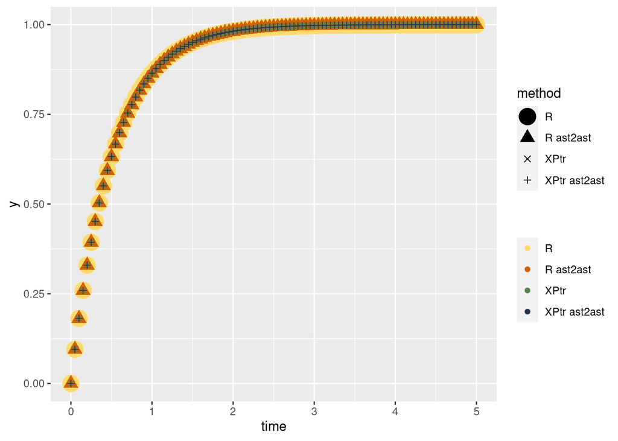

```r
res4 <- solve_ode(pointer_to_ode,
                      ti, y0)
res4 <- as.vector(res4)




# Rfunction-ast2ast version
# ==============================================================================
ode <- function(t, y, p, psens) {
  nu_db <- 2
  a_db <- 1
  return(-nu_db*(y - a_db))
}

odecpp <- translate(ode)

ti <- seq(0, 5, length.out=101)
y0 <- 0
res2 <- r2cvodes(y0, ti,
                    odecpp, param = p)


# check results and conduct benchmnark
# ==============================================================================
df <- data.frame(time = rep(ti, 4),
                 method = c(rep("R", 101), rep("R ast2ast", 101),
                            rep("XPtr", 101), rep("XPtr ast2ast", 101) ),
                 y = c(res1, res2, res3, res4))

library(ggplot2)
ggplot() +
  geom_point(data = df, aes(x = time, y = y,
                            colour = method, shape = method,
                            group = method, size = method) ) +
  scale_colour_manual(values = c("#FFDB6D", "#D16103", "#52854C", "#293352") ) +
  scale_size_manual(values = c(6, 4, 2, 1.5)) +
  scale_shape_manual(values=c(19,17,4, 3)) +
  labs(colour = "")
```

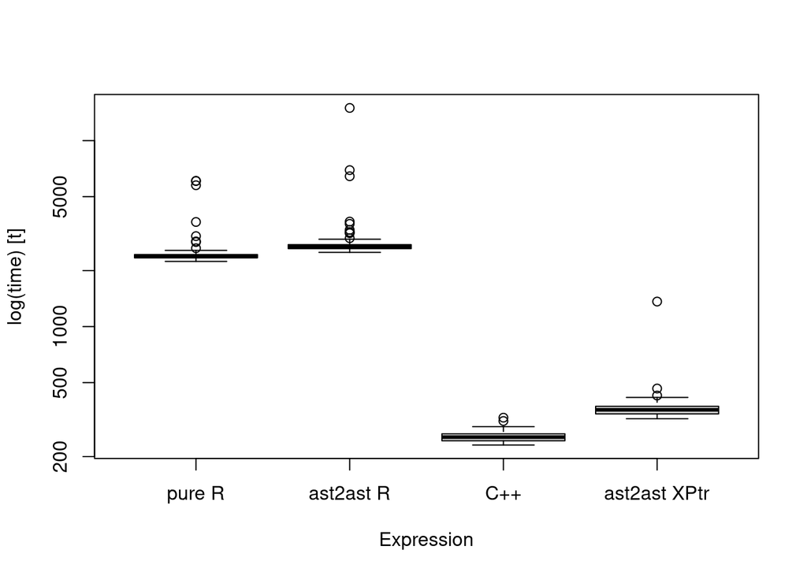

```r
r <- microbenchmark::microbenchmark(
                               r2cvodes(y0, ti,
                                        frhs, param = p),
                               r2cvodes(y0, ti,
                                        odecpp, param = p),
                               r2sundials::r2cvodes(y0, ti, ptr_exp, param=pv),
                               solve_ode(pointer_to_ode,
                                                     ti, y0))
boxplot(r, names = c("pure R", "ast2ast R", "C++", "ast2ast XPtr"))
```